# Regression Analysis on Crime

**Import Packages and IDE Prep**

```r
#rm(list = ls())
library(car)
library(rstatix)
set.seed(2)
options(scipen=999)
```

**Read in Dataset(s)**

```r
crime_dataset = read.table('uscrime.txt',header = TRUE)
head(crime_dataset,5)
```

```
##      M So   Ed  Po1  Po2    LF   M.F Pop   NW    U1  U2 Wealth Ineq     Prob
## 1 15.1  1  9.1  5.8  5.6 0.510  95.0  33 30.1 0.108 4.1   3940 26.1 0.084602
## 2 14.3  0 11.3 10.3  9.5 0.583 101.2  13 10.2 0.096 3.6   5570 19.4 0.029599
## 3 14.2  1  8.9  4.5  4.4 0.533  96.9  18 21.9 0.094 3.3   3180 25.0 0.083401
## 4 13.6  0 12.1 14.9 14.1 0.577  99.4 157  8.0 0.102 3.9   6730 16.7 0.015801
## 5 14.1  0 12.1 10.9 10.1 0.591  98.5  18  3.0 0.091 2.0   5780 17.4 0.041399
##      Time Crime
## 1 26.2011   791
## 2 25.2999  1635
## 3 24.3006   578
## 4 29.9012  1969
## 5 21.2998  1234
```

**Exploratory Data Analysis**

```r
#dimensions
dim(crime_dataset)
```

```
## [1] 47 16
```

```r
#summary stats
summary(crime_dataset)
```

```
##        M               So               Ed             Po1
##  Min.   :11.90   Min.   :0.0000   Min.   : 8.70   Min.   : 4.50
##  1st Qu.:13.00   1st Qu.:0.0000   1st Qu.: 9.75   1st Qu.: 6.25
##  Median :13.60   Median :0.0000   Median :10.80   Median : 7.80
##  Mean   :13.86   Mean   :0.3404   Mean   :10.56   Mean   : 8.50
##  3rd Qu.:14.60   3rd Qu.:1.0000   3rd Qu.:11.45   3rd Qu.:10.45
##  Max.   :17.70   Max.   :1.0000   Max.   :12.20   Max.   :16.60
##       Po2               LF              M.F              Pop
##  Min.   : 4.100   Min.   :0.4800   Min.   : 93.40   Min.   :  3.00
##  1st Qu.: 5.850   1st Qu.:0.5305   1st Qu.: 96.45   1st Qu.: 10.00
##  Median : 7.300   Median :0.5600   Median : 97.70   Median : 25.00
##  Mean   : 8.023   Mean   :0.5612   Mean   : 98.30   Mean   : 36.62
##  3rd Qu.: 9.700   3rd Qu.:0.5930   3rd Qu.: 99.20   3rd Qu.: 41.50
##  Max.   :15.700   Max.   :0.6410   Max.   :107.10   Max.   :168.00
##        NW              U1                U2            Wealth
##  Min.   : 0.20   Min.   :0.07000   Min.   :2.000   Min.   :2880
##  1st Qu.: 2.40   1st Qu.:0.08050   1st Qu.:2.750   1st Qu.:4595
##  Median : 7.60   Median :0.09200   Median :3.400   Median :5370
##  Mean   :10.11   Mean   :0.09547   Mean   :3.398   Mean   :5254
##  3rd Qu.:13.25   3rd Qu.:0.10400   3rd Qu.:3.850   3rd Qu.:5915
##  Max.   :42.30   Max.   :0.14200   Max.   :5.800   Max.   :6890
##       Ineq            Prob              Time           Crime
##  Min.   :12.60   Min.   :0.00690   Min.   :12.20   Min.   : 342.0
##  1st Qu.:16.55   1st Qu.:0.03270   1st Qu.:21.60   1st Qu.: 658.5
##  Median :17.60   Median :0.04210   Median :25.80   Median : 831.0
##  Mean   :19.40   Mean   :0.04709   Mean   :26.60   Mean   : 905.1
##  3rd Qu.:22.75   3rd Qu.:0.05445   3rd Qu.:30.45   3rd Qu.:1057.5
##  Max.   :27.60   Max.   :0.11980   Max.   :44.00   Max.   :1993.0
```

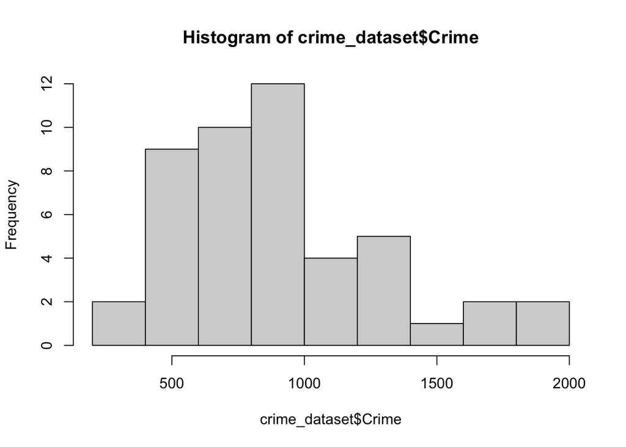

```r
#Visualizations
hist(crime_dataset$Crime)
```

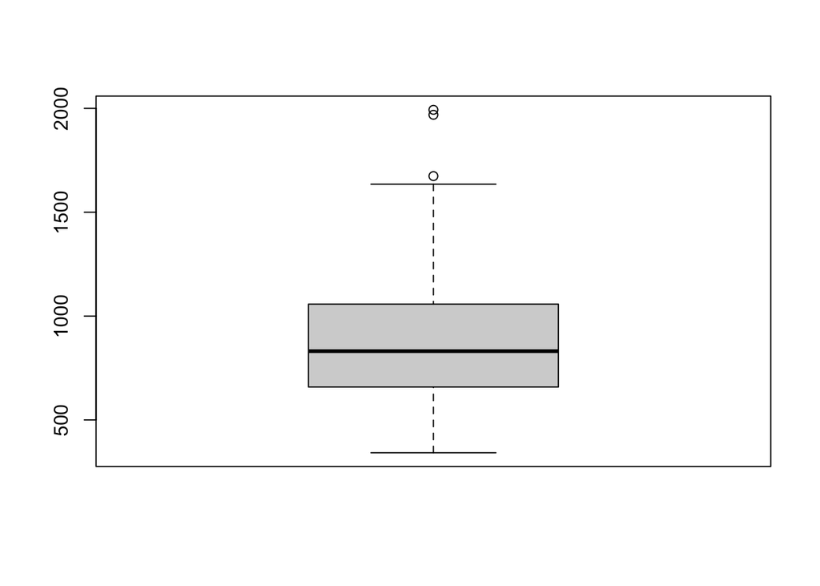

```r
boxplot(crime_dataset$Crime)
```

```r
boxplot.stats(crime_dataset$Crime)$out
```

```
## [1] 1969 1674 1993
```

```r
#outlier identification
identify_outliers(
  data = crime_dataset,
  variable = "Crime"
)
```

```
##      M So   Ed  Po1  Po2    LF   M.F Pop   NW    U1  U2 Wealth Ineq     Prob
## 1 13.6  0 12.1 14.9 14.1 0.577  99.4 157  8.0 0.102 3.9   6730 16.7 0.015801
## 2 12.4  0 10.5 12.1 11.6 0.580  96.6 101 10.6 0.077 3.5   6570 17.0 0.016201
## 3 13.1  0 12.1 16.0 14.3 0.631 107.1   3  7.7 0.102 4.1   6740 15.2 0.041698
##      Time Crime is.outlier is.extreme
## 1 29.9012  1969       TRUE      FALSE
## 2 41.6000  1674       TRUE      FALSE
## 3 22.1005  1993       TRUE      FALSE
```

**Creating Linear Regression Model on Crime**

```r
model_lm = lm(Crime~., data = crime_dataset)
summary(model_lm)
```

```
##
## Call:
## lm(formula = Crime ~ ., data = crime_dataset)
##
## Residuals:
##     Min      1Q  Median      3Q     Max
## -395.74  -98.09   -6.69  112.99  512.67
##
## Coefficients:
##                Estimate  Std. Error t value Pr(>|t|)
## (Intercept) -5984.28760  1628.31837  -3.675 0.000893 ***
## M              87.83017    41.71387   2.106 0.043443 *
## So             -3.80345   148.75514  -0.026 0.979765
## Ed            188.32431    62.08838   3.033 0.004861 **
## Po1           192.80434   106.10968   1.817 0.078892 .
## Po2          -109.42193   117.47754  -0.931 0.358830
## LF           -663.82615  1469.72882  -0.452 0.654654
## M.F            17.40686    20.35384   0.855 0.398995
## Pop            -0.73301     1.28956  -0.568 0.573845
## NW              4.20446     6.48089   0.649 0.521279
## U1          -5827.10272  4210.28904  -1.384 0.176238
## U2            167.79967    82.33596   2.038 0.050161 .
## Wealth          0.09617     0.10367   0.928 0.360754
## Ineq           70.67210    22.71652   3.111 0.003983 **
## Prob        -4855.26582  2272.37462  -2.137 0.040627 *
## Time           -3.47902     7.16528  -0.486 0.630708
## ---
## Signif. codes:  0 '***' 0.001 '**' 0.01 '*' 0.05 '.' 0.1 ' ' 1
##
## Residual standard error: 209.1 on 31 degrees of freedom
## Multiple R-squared:  0.8031, Adjusted R-squared:  0.7078
## F-statistic: 8.429 on 15 and 31 DF,  p-value: 0.0000003539
```

```r
##Using AIC to estimate quality of model
AIC(model_lm)
```

```
## [1] 650.0291
```

**AIC = 650.03** **R-squared = 80.31%**

**Plot lm model** **Lets plot the Ineq against Crime & Ed against Crime since they have the lowest p-values**

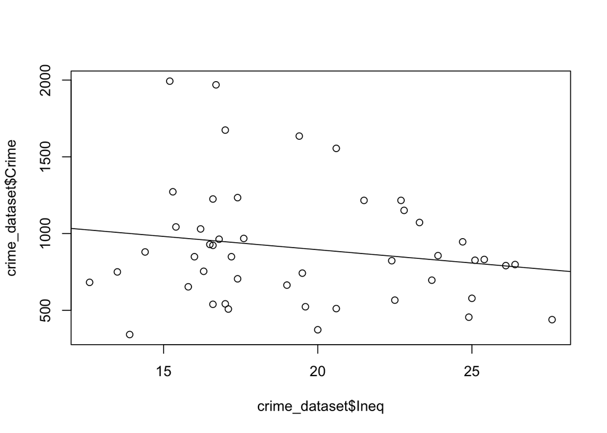

```r
plot(crime_dataset$Ineq,crime_dataset$Crime)
abline(lm(Crime ~ Ineq, data = crime_dataset))
```

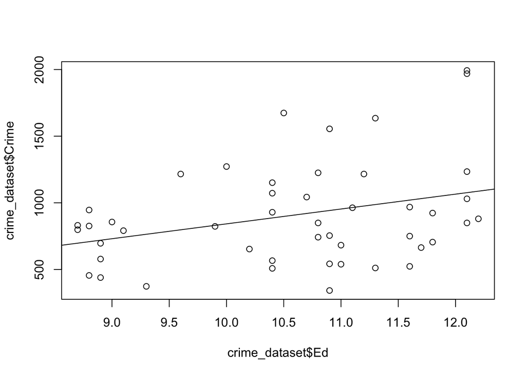

```r
plot(crime_dataset$Ed,crime_dataset$Crime)
abline(lm(Crime ~ Ed, data = crime_dataset))
```

**Although the regression lines don’t seem to show much correlation, we do know there is some correlation and therefore requires further analysis**

**Partial regression plots to plot multiple predictors linear regression**

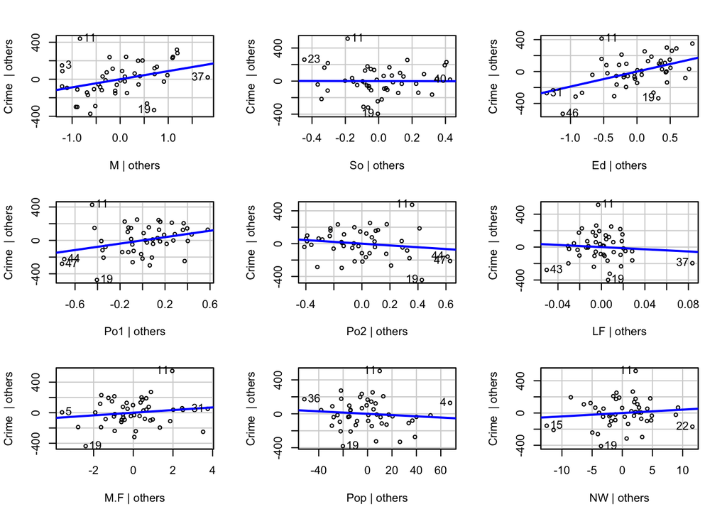

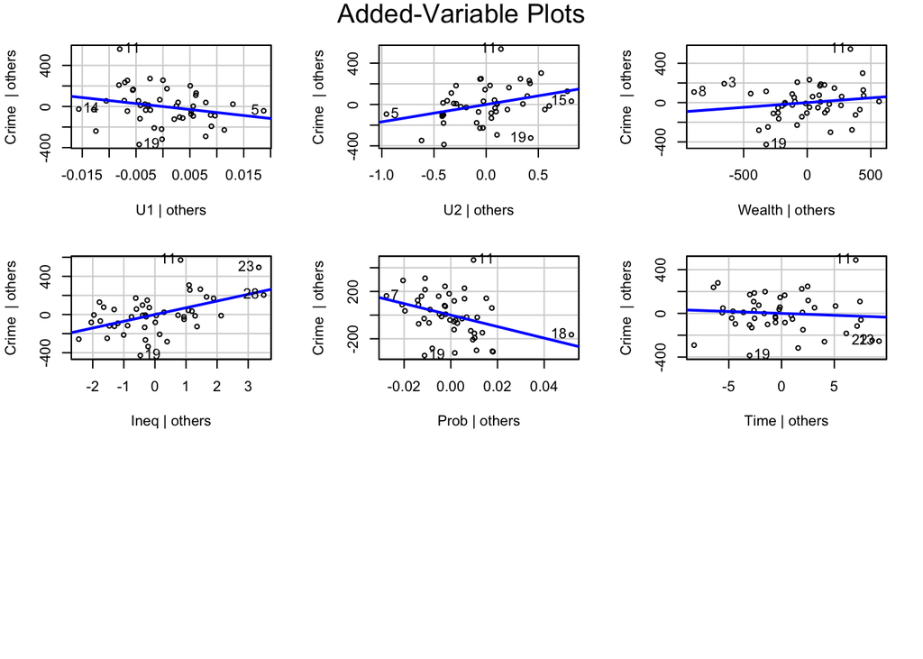

```r
avPlots(model_lm)
```

**We can see that the partial regression plots do show some correlation, though none of the predictors stand out as perfectly correlated to Crime**

**Let’s use stepwise regression to automatically select predictors to use in a regression model** **Stepwise regression removes/adds predictors one at a time and uses statistical significance to find the best model.**

```r
step(model_lm)
```

```
## Start:  AIC=514.65
## Crime ~ M + So + Ed + Po1 + Po2 + LF + M.F + Pop + NW + U1 +
##     U2 + Wealth + Ineq + Prob + Time
##
##          Df Sum of Sq     RSS    AIC
## - So      1        29 1354974 512.65
## - LF      1      8917 1363862 512.96
## - Time    1     10304 1365250 513.00
## - Pop     1     14122 1369068 513.14
## - NW      1     18395 1373341 513.28
## - M.F     1     31967 1386913 513.74
## - Wealth  1     37613 1392558 513.94
## - Po2     1     37919 1392865 513.95
## <none>                1354946 514.65
## - U1      1     83722 1438668 515.47
## - Po1     1    144306 1499252 517.41
## - U2      1    181536 1536482 518.56
## - M       1    193770 1548716 518.93
## - Prob    1    199538 1554484 519.11
## - Ed      1    402117 1757063 524.86
## - Ineq    1    423031 1777977 525.42
##
## Step:  AIC=512.65
## Crime ~ M + Ed + Po1 + Po2 + LF + M.F + Pop + NW + U1 + U2 +
##     Wealth + Ineq + Prob + Time
##
##          Df Sum of Sq     RSS    AIC
## - Time    1     10341 1365315 511.01
## - LF      1     10878 1365852 511.03
## - Pop     1     14127 1369101 511.14
## - NW      1     21626 1376600 511.39
## - M.F     1     32449 1387423 511.76
## - Po2     1     37954 1392929 511.95
## - Wealth  1     39223 1394197 511.99
## <none>                1354974 512.65
## - U1      1     96420 1451395 513.88
## - Po1     1    144302 1499277 515.41
## - U2      1    189859 1544834 516.81
## - M       1    195084 1550059 516.97
## - Prob    1    204463 1559437 517.26
```

[output cut: 90 more lines]

```
## - Po1     1   1127277 2553852 530.44
##
## Step:  AIC=503.93
## Crime ~ M + Ed + Po1 + M.F + U1 + U2 + Ineq + Prob
##
##        Df Sum of Sq     RSS    AIC
## <none>              1453068 503.93
## - M.F   1    103159 1556227 505.16
## - U1    1    127044 1580112 505.87
## - Prob  1    247978 1701046 509.34
## - U2    1    255443 1708511 509.55
## - M     1    296790 1749858 510.67
## - Ed    1    445788 1898855 514.51
## - Ineq  1    738244 2191312 521.24
## - Po1   1   1672038 3125105 537.93
```

```
##
## Call:
## lm(formula = Crime ~ M + Ed + Po1 + M.F + U1 + U2 + Ineq + Prob,
##     data = crime_dataset)
##
## Coefficients:
## (Intercept)            M           Ed          Po1          M.F           U1
##    -6426.10        93.32       180.12       102.65        22.34     -6086.63
##          U2         Ineq         Prob
##      187.35        61.33     -3796.03
```

```r
#create model from stepwise analysis
stepwise_lm = lm(formula = Crime ~ M + Ed + Po1 + M.F + U1 + U2 + Ineq + Prob,
   data = crime_dataset)
```

**Stepwise LM model: Crime = 93.32M + 180.12Ed + 102.65Po1 + 22.34M.F - 6086.63 U1 + 187.35U2 + 61.33Ineq - 3796.03Prob - 6426.10**

**AIC = 639.32** **R-squared = 78.89%**

**Lets compare quality of each model.**

```r
cat('AIC for 15 Predictor LM:',AIC(model_lm))
```

```
## AIC for 15 Predictor LM: 650.0291
```

```r
cat('R-squared for 15 Predictor LM:',summary(model_lm)$r.squared *100)
```

```
## R-squared for 15 Predictor LM: 80.30868
```

```r
cat('AIC for 8 Predictor Stepwise LM:',AIC(stepwise_lm))
```

```
## AIC for 8 Predictor Stepwise LM: 639.3151
```

```r
cat('R-squared for 8 Predictor Stepwise LM:',summary(stepwise_lm)$r.squared *100)
```

```
## R-squared for 8 Predictor Stepwise LM: 78.88268
```

**Comparing the AIC of the 15 predictor model to the stepwise optimized 8 predictor model we see that the stepwise model has a lower AIC. We also see that the R-squared values are similar between the models. This signals there is some overfitting in the 15 predictor model. This also suggests the quality of the 8 predictor model’s fit is greater than the larger model. As next steps we can also split the data into train and test datasets for further quality evaluation.**

**Predicting Crime output.**

```r
##configure prediction vector
new_predict_row = c(14.0,0,10.0,12.0,15.5,0.640,94.0,150,1.1,0.120,3.6,3200,20.1,0.04,39.0)

crime_predict_on = crime_dataset

crime_predict_on = crime_predict_on[-c(1:47),-16 ]

crime_predict_on[nrow(crime_predict_on)+1,] = new_predict_row

crime_predict_on ##check new dataframe
```

```
##    M So Ed Po1  Po2   LF M.F Pop  NW   U1  U2 Wealth Ineq Prob Time
## 1 14  0 10  12 15.5 0.64  94 150 1.1 0.12 3.6   3200 20.1 0.04   39
```

```r
##predictions
#predict on 15 predictor model
predict(model_lm, newdata = crime_predict_on)
```

```
##        1
## 155.4349
```

```r
#predict on 8 predictor model
predict(stepwise_lm, newdata = crime_predict_on)
```

```
##        1
## 1038.413
```

**The larger 15 predictor model predicts a Crime value of 155 while the stepwise 8 predictor model predicts a much larger Crime value of 1038. These values are in stark contrast to each other. However, looking back at the quantile Crime values from our earlier analysis we see that 155 is lower than the minimum Crime value of 342. This might make the value of 155 an outlier. The stepwise model’s prediction of 1038 is much more in line with the quantile values as this value would fit in within the 3rd quantile of Crime values. Given the quality of fit for the stepwise model and our findings here I’m more inclined to trust the stepwise model’s predictions over the larger model’s predictions.**